# bioinfomodule 2025

Johannes Wolter

2025-11-27

# Expression analysis with R and the tidyverse

## 1 Intro and Overview

### 1.1 R and RStudio

Make sure that R and RStudio are installed in your computer. You can create a new R Script in RStudio to copy example source code from this tutorial and write code for the exercises (when you open RStudio the console will be open. Make sure you go to file and create a script and work from there). Save the script in your home directory (or a sub directory of your choice). To run the code written on the current line (or of selected lines), click on button Run or press CTRL+ENTER. Results will be displayed either in the RStudio’s console or the Viewer panel (graphics). To read the documentation about a function (Help panel), in the script, place the cursor on the function’s name and press F1. You should use this feature extensively here, as many answers to possible questions are hidden here :)

before anything else let us create a new project. Go to File -> new Project (in the bar on top) and create a bioinfo-module directory, or chose one, if you have already created one. Now go to File -> new File -> R script to create the file you will be working in. Now you should have the script where we code on the top half, and the Terminal where we see the results of the executed code on the bottom.

### 1.2 package installation

The packages we’ll need can be installed with the following code: Note the comment lines, which can be used in R code to tell the interpreter to not read the text as code. They will will tell you a bit more about what you are installing! :)

```r
dir.create("~/Rlib")
Rlib = "~/Rlib"
.libPaths(Rlib)
# now R should install into your custom lib and also read from there. If it does
#not work, specify the lib for installing and loading like this, and do not update
#the standard packages if possible (choose n when asked "Update a/s/n?")
#otherwise it is possible to install the standard r libraries into your custom lib,
#but I hope that is not necessary

install.packages("tidyverse", lib=Rlib)
library(tidyverse, lib=Rlib)

if (!requireNamespace("BiocManager", quietly = TRUE))
  install.packages("BiocManager", lib=Rlib)
library(BiocManager)

# pls install the packages one by one, so excexute th elines one by one. If you are asked to update packages
# choose no

BiocManager::install("limma", lib=Rlib, dependencies = TRUE, force=TRUE)
# BiocManager::install("EnhancedVolcano", lib=Rlib)
BiocManager::install("ComplexHeatmap", lib=Rlib)
BiocManager::install("fgsea", lib=Rlib)
BiocManager::install("pheatmap", lib=Rlib)
BiocManager::install("biomaRt", lib=Rlib)
BiocManager::install("msigdbr", lib=Rlib)

# the problem is, that the directory in which R is installed is in an area where you are not
# allowed to create or change/update files in. This is why we need to create a new one, and tell
# R to check for packages there first.

# Please be patient, and start reading the rest of the script while things install. It can take a while
# on the ZDV computers...
```

```r
BiocManager::install("sva", lib=Rlib, dependencies = TRUE, force=TRUE)
BiocManager::install("GenomeInfoDbData", lib=Rlib)
BiocManager::install("genefilter", lib=Rlib)
install.packages("tidyverse", lib=Rlib)

library(tidyverse)
library(limma) # differential analysis
library(stats) # standard R pkg for statistics, we'll use its PCA implementation
library(sva) # batch effect stuff

library(pheatmap)
library(msigdbr)
# library(biomaRt)  #if u load it earlier there is a conflict with select()
# can we use dplyr::select() or something like this?
library(fgsea)
```

## 0. R basics you need for this module

This course is not a full R programming class, but there are a few core ideas you’ll use all the time.  
We’ll use short examples with made-up numbers first, then apply the same ideas to gene expression data.

```r
# Assignment with <-
# Think of "<-" as "gets"
x <- 5          # x gets the value 5
y <- 10
x + y           # 15
```

```
## [1] 15
```

```r
# Vectors: ordered lists of values
heights <- c(160, 172, 168, 181)   # numeric vector
groups  <- c("Normal", "Tumor", "Normal", "Tumor")  # character vector

heights
```

```
## [1] 160 172 168 181
```

```r
groups
```

```
## [1] "Normal" "Tumor"  "Normal" "Tumor"
```

```r
# Data frames / tibbles: tables (rows = observations, columns = variables)
library(tidyverse)

samples <- tibble(
  ID     = c("sample1", "sample2", "sample3", "sample4"),
  class  = groups,
  height = heights
)

samples
```

```
## # A tibble: 4 × 3
##   ID      class  height
##   <chr>   <chr>   <dbl>
## 1 sample1 Normal    160
## 2 sample2 Tumor     172
## 3 sample3 Normal    168
## 4 sample4 Tumor     181
```

## The pipe operator %>%

The pipe means: “Take the thing on the left, and give it to the function on the right”

This lets us read code from left to right, like a sentence.

```r
# without the pipe operator:
samples_filtered <- filter(samples, class == "Tumor")
samples_filtered <- select(samples_filtered, ID, height)

samples_filtered
```

```
## # A tibble: 2 × 2
##   ID      height
##   <chr>    <dbl>
## 1 sample2    172
## 2 sample4    181
```

```r
# with the pipe operator:
samples_filtered2 <- samples %>%
filter(class == "Tumor") %>% # keep only rows where class == "Tumor"
select(ID, height) # keep only these columns

samples_filtered2
```

```
## # A tibble: 2 × 2
##   ID      height
##   <chr>    <dbl>
## 1 sample2    172
## 2 sample4    181
```

```r
# Add a new column with mutate()

samples %>%
mutate(height_m = height / 100)   # convert cm → meters
```

```
## # A tibble: 4 × 4
##   ID      class  height height_m
##   <chr>   <chr>   <dbl>    <dbl>
## 1 sample1 Normal    160     1.6
## 2 sample2 Tumor     172     1.72
## 3 sample3 Normal    168     1.68
## 4 sample4 Tumor     181     1.81
```

```r
# Group + summarise

samples %>%
group_by(class) %>%
summarise(mean_height = mean(height))
```

```
## # A tibble: 2 × 2
##   class  mean_height
##   <chr>        <dbl>
## 1 Normal        164
## 2 Tumor         176.
```

## Row names vs. columns

Expression data often stores sample IDs as row names (not as a column). We’ll convert back and forth using:

column_to_rownames()

rownames_to_column()

```r
toy <- tibble(
ID = c("sample1", "sample2"),
class = c("Normal", "Tumor"),
geneA = c(10, 50)
)

toy
```

```
## # A tibble: 2 × 3
##   ID      class  geneA
##   <chr>   <chr>  <dbl>
## 1 sample1 Normal    10
## 2 sample2 Tumor     50
```

```r
# Convert ID column → row names

toy_df <- toy %>%
column_to_rownames("ID") %>%
as.data.frame()

toy_df
```

```
##          class geneA
## sample1 Normal    10
## sample2  Tumor    50
```

```r
# Convert row names → ID column

toy_df %>%
rownames_to_column("ID")
```

```
##        ID  class geneA
## 1 sample1 Normal    10
## 2 sample2  Tumor    50
```

## $ — Accessing a column by name

$ is used to extract a column from a data frame or tibble.

Think: “inside this table, give me the column named ___”

```r
samples <- tibble(
ID = c("sample1", "sample2", "sample3"),
class = c("Normal", "Tumor", "Normal"),
height = c(160, 172, 168)
)

samples$class # vector: "Normal" "Tumor" "Normal"
```

```
## [1] "Normal" "Tumor"  "Normal"
```

```r
samples$height # vector: 160 172 168
```

```
## [1] 160 172 168
```

## () — Calling a function

Parentheses always mean “run a function with these arguments”.

```r
mean(heights) # compute a mean
```

```
## [1] 170.25
```

```r
filter(samples, class == "Tumor") # filter rows
```

```
## # A tibble: 1 × 3
##   ID      class height
##   <chr>   <chr>  <dbl>
## 1 sample2 Tumor    172
```

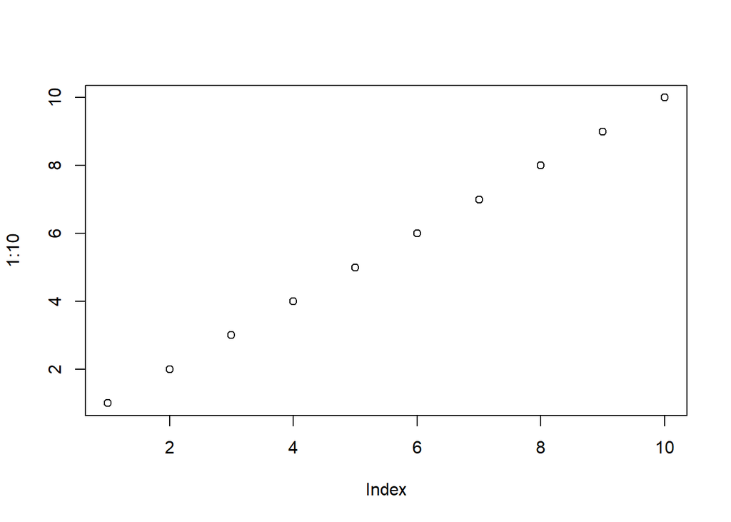

```r
plot(1:10) # create a plot
```

## [] — Extract rows and columns

Square brackets are for subsetting.

For data frames and matrices: object[rows, columns]

```r
# Our samples tibble:
samples
```

```
## # A tibble: 3 × 3
##   ID      class  height
##   <chr>   <chr>   <dbl>
## 1 sample1 Normal    160
## 2 sample2 Tumor     172
## 3 sample3 Normal    168
```

```r
samples[2:3, ] # rows 2 and 3
```

```
## # A tibble: 2 × 3
##   ID      class  height
##   <chr>   <chr>   <dbl>
## 1 sample2 Tumor     172
## 2 sample3 Normal    168
```

```r
samples[, 1] # first column (ID)
```

```
## # A tibble: 3 × 1
##   ID
##   <chr>
## 1 sample1
## 2 sample2
## 3 sample3
```

```r
samples[, 3] # third column (height)
```

```
## # A tibble: 3 × 1
##   height
##    <dbl>
## 1    160
## 2    172
## 3    168
```

```r
samples[, "class"] # same as samples$class
```

```
## # A tibble: 3 × 1
##   class
##   <chr>
## 1 Normal
## 2 Tumor
## 3 Normal
```

```r
samples[1:2, "height"]
```

```
## # A tibble: 2 × 1
##   height
##    <dbl>
## 1    160
## 2    172
```

## Putting it together

Everything later — PCA, DE analysis, SVA — builds on these tiny building blocks:

assign (<-)

pipe (%>%)

select / filter / mutate

tibbles

rownames ↔︎ columns

If a pipeline step confuses you later, come back to this section and maybe it helps a little bit (:

## Exercise 0: Working with tables using $, [], and %>%

We will use the same tiny example table as before.

```r
toy <- tibble(
ID = c("sample1", "sample2"),
class = c("Normal", "Tumor"),
geneA = c(10, 50)
)

toy
```

- Extract the geneA column using $ and save it in a variable called geneA_values. geneA_values <- …
- Use square brackets to:
  - get the first row
  - get only the class column
  - get the geneA value for sample2

```r
#first row

toy[ ... , ]

#class column

toy[ , ... ]

#geneA value of sample2

toy[ ... , ... ]
```

- Using the pipe:

  Filter only the Tumor sample

  Keep only the ID and geneA columns

```r
toy %>%
filter( ... ) %>% # keep tumor
select( ... ) # keep ID + geneA
```

- Create a new column called geneA_log2 that is the log2 of geneA.

```r
toy %>%
mutate(geneA_log2 = ...) # hint: use log2()
```

Here is the block from before (kept exactly as you had it):

```r
toy_df <- toy %>%
column_to_rownames("ID") %>%
as.data.frame()

toy_df

toy_df %>%
rownames_to_column("ID")
```

- Extract JUST the geneA value for sample1 from toy_df using [].
- Convert rownames back into a column and filter only the Tumor sample using the pipe.

```r
# geneA of sample1

toy_df[ ... , ... ]

# convert rownames → column and filter

toy_df %>%
rownames_to_column("ID") %>%
filter( ... )
```

Mini “real-data” simulation (important)

This is exactly what we will do later with thousands of genes.

Below is a fake counts table with 3 genes and 3 samples:

```r
mini_counts <- tibble(
ID = c("gene1", "gene2", "gene3"),
sampleA = c(10, 50, 0),
sampleB = c(20, 40, 5),
sampleC = c(15, 55, 10)
)

mini_counts
```

Your tasks:

- Convert the ID column to rownames.
- Extract the expression values of gene2.
- Extract the expression values for sampleC.
- Convert back to a tibble and keep only genes with count > 10 in sampleB.

Reflection:

Why is the pipe %>% helpful when working with large tables?

Why is it important to know how to extract rows/columns with []?

What changes when you move sample IDs into rownames?

# Now, this is where the bioinformatics starts (:

## Introduction

Because of the ever-growing number of publicly available and large datasets in life sciences, computational and statistical skills are becoming a key part of the life scientist’s curriculum. This tutorial aims to give you an overview on how to load and convert data in R and how to do exploratory analysis, prior to delving deeper into downstream analysis of differential expression and gene set enrichments.

While microarrays are still in use and can be especially useful when interested in a specific set of genes (Custom Arrays), RNA-seq is the main sourch for expression data nowadays. Nevertheless, many techniques, use for RNA-seq count data, in this course are directly - or with minor changes - applicabkle to microarray data too.

The basic workflow for RNA-seq and computational analysis can be seen in the figures below:

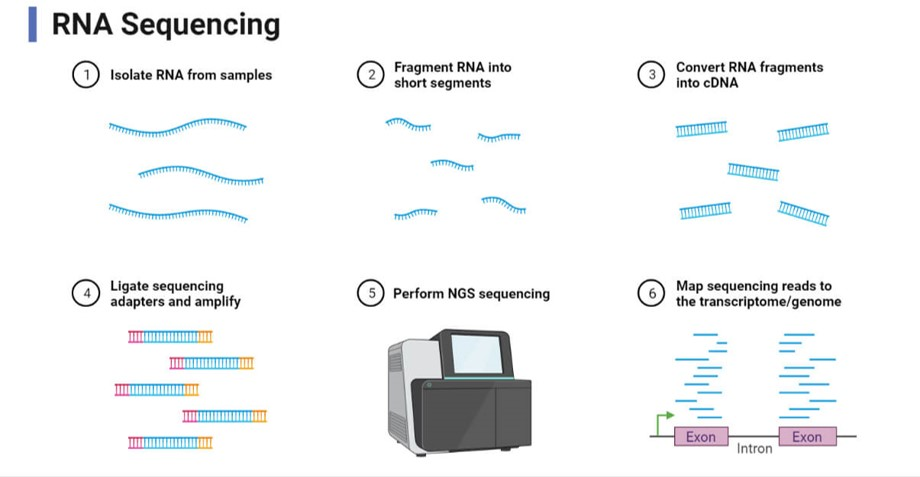

RNA Sequencing

**Automated Quality Control with ML:** If you are interested in the quality control of FASTQ files, inRNA-seq as well as other functional genmoics data, have a look at our work predicting sample quality with machine learning: Quality prediction: https://genomebiology.biomedcentral.com/articles/10.1186/s13059-021-02294-2 Batch effect detection with the same software: https://bmcbioinformatics.biomedcentral.com/articles/10.1186/s12859-022-04775-y

## Overview

The R language comes with many functions already working, such as arithmetic and logical operators, built-in functions like dim(), str(), min(), max(), mean() and much more. As a programming language it also features control structures like loops and allows you to write your own functions. It is an object-oriented languae that allows, which allows to pack information from multiple sources into one object, which is often utilized as such by the bioinformatics packages and which we will also encounter.

### RLang, packages and libraries

The base language of R was meant for statistical programming and data visualization, but has been expanded by its community with packages for multiple scietific and programmatic purposes. Especially, for data science, machine learning and bioinformatics. Most packages that handle bioinformatics are available through BioConductor a project dedicated to building and maintaining bioinformatic software:

The mission of the Bioconductor project is to develop, support, and disseminate free open source software that facilitates rigorous and reproducible analysis of data from current and emerging biological assays. We are dedicated to building a diverse, collaborative, and welcoming community of developers and data scientists.

To use the packages mentioned above, we’ll install them first. You should have tried it already in the prerequisites section. If it worked out, we can load the packages - or libraries - by calling the library() function.

## Import Datasets and Objects

### The Dataset

Top run any analysis, we first need our data of course. We’ll get our data from an already prepossessed and curated dataset source called BARRA:CuRDa - weird name I know - but we’ll not take the complete set but only choose some sets. The database, with it’s downloadable datasets and the paper can be found here: https://sbcb.inf.ufrgs.br/barracurda. The authors of the database and paper, have used the following workflow, you’ll notice some overlaps with what was discussed in the Introduction.

[figure not shown]

Barracurda

The dataset was picked and curated to be optimal for machine learning and benchmarked for multiple algorithms. We’ll explore some of that in the second week of the course and compare our differential genes with what the ML algorithms deem as important in our data. First, we’ll focus on exploratory and differential analysis though. We’ll start out with the Head and Neck Cancer datasets GSEGSE64912 and GSEGSE68799. you can get them from their site: https://sbcb.inf.ufrgs.br/barracurda Or in case the site is down (which happened before…) you can download them from my google drive: https://drive.google.com/file/d/1GWWB_8F_pbXzEPX4p6YDo-Mm3KjlFu39/view?usp=sharing https://drive.google.com/file/d/1-04BZvr_tFaiQNM-QqO6nLlOMbJTmgIc/view?usp=drive_link

## Importing Data into R

To separate the content of each cell in a file, people use special characters like commas, tabs, pipes, etc. The extension of plain-text files is often a good hint of what delimiter has been used. For example, csv files should use “commas” as the delimiter, whereas tsv files should use “tabs”. Nevertheless, you can find csv or tsv files that are delimited with different characters.

The first step in data import is locating the file in your computer or in a remote location (e.g. by URL). The most important parameter for readr’s functions is the path to the file of interest.

In this part, you are going to import files located on your machine that you either downloaded from the link above or froim your course files. The tidyverse library must be loaded.

### Where are we?

Before actually importing the data: We need to check where our current working directory is and if our files are in a relative path or not. If it is not the case we can either choose to include their whole path or set up our working directory in such a way, that we can work from the dedicated folder for the project and have our data and output in the same directory as sub directories. When we set up our working directory, we can download the data files and deposit them in the data/input folder.

```r
# returns the current working dir
getwd()
setwd("~/")
# sets the current working dir to its input
setwd(getwd())
# setwd() needs an input, otherwise throws an error! :)
# setwd(getwd()) sets the current working directory as the new working directory, so it does nothing

# file.path() is a helper function, that glues together multiple input strings to a file path.
# to set a completely new path:
# either
# setwd(file.path("C:", "Some", "random", "path"))
# or
# setwd("C:/some/random/path")

# you can use the file browser in RStudio as shown below as well :)

# set a path relative to the current working directory, and call it whatever makes sense to you
# for example:
dir.create("bioinfo-module/IamForcedToLearnR/IamInRjail/SendHelp", recursive = TRUE)
setwd(file.path(getwd(), "bioinfo-module"))
```

[figure not shown]

help1

### Exercise 1: Set up your environment

To set up your working dir, you can either work in your respective OS and create a folder called “Bioinfo-module” and set this as the wording dir with the setwd() function.

Or you can create it from RStudio directly, with the dir.create() function.

Now we can set up our input and output directories, which we’ll use to have a bit of structure in our working directory.

```r
### don't forget to set your working directory first! ###

# assign variables to names of out folders (these could also be whole paths, pointing somewhere else entirely!)
out.dir <- "output"
in.dir <- "data"

# Create the directories only if they don't exist
if (!dir.exists(out.dir)) {
  dir.create(out.dir)
}

if (!dir.exists(in.dir)) {
  dir.create(in.dir)
}
```

Now you need to deposit the data in the dedicated folder. Note that these files are zipped and need to be unzipped in their destination folder (smaller files can be read in zipped, however files of these size take their time and I don’t want to risk it on the NatFak machines :D).

### Importing a csv file

First, we’ll import a single file

```r
test <- read_csv(file.path(in.dir, "GSE68799.csv"))
test
```

```
## # A tibble: 45 × 58,737
##    ID      class ENSG00000000003 ENSG00000000005 ENSG00000000419 ENSG00000000457
##    <chr>   <chr>           <dbl>           <dbl>           <dbl>           <dbl>
##  1 SRR201… Tumor            9.34            1.72            9.41            9.33
##  2 SRR201… Tumor            9.02            1.72            9.48            9.95
##  3 SRR201… Norm…            7.12            2.52           10.1             9.01
##  4 SRR201… Tumor            9.15            2.57            9.53            9.61
##  5 SRR201… Tumor           10.1             2.81            9.70            9.44
##  6 SRR201… Tumor            9.58            2.40            9.41            9.64
##  7 SRR201… Tumor           10.1             1.72            9.62            9.26
##  8 SRR201… Tumor           10.7             2.56           10.6             9.77
##  9 SRR201… Tumor            9.62            1.72           10.2             9.48
## 10 SRR201… Tumor            9.82            1.72           10.4             9.65
## # ℹ 35 more rows
## # ℹ 58,731 more variables: ENSG00000000460 <dbl>, ENSG00000000938 <dbl>,
## #   ENSG00000000971 <dbl>, ENSG00000001036 <dbl>, ENSG00000001084 <dbl>,
## #   ENSG00000001167 <dbl>, ENSG00000001460 <dbl>, ENSG00000001461 <dbl>,
## #   ENSG00000001497 <dbl>, ENSG00000001561 <dbl>, ENSG00000001617 <dbl>,
## #   ENSG00000001626 <dbl>, ENSG00000001629 <dbl>, ENSG00000001630 <dbl>,
## #   ENSG00000001631 <dbl>, ENSG00000002016 <dbl>, ENSG00000002079 <dbl>, …
```

Well that worked out well! Note how simple the syntax for data import is: you choose the name of a variable to store your table, use the <- operator (written with 2 characters: < and -), call the appropriate readr function and specify the location of your file. So now we’ll get all files in the input folder and read in each of them. additionally, we’ll save the names of the respective files, so that we can keep that info for later.

```r
# get the file names in the directory with the csv ending, note that this will only return the names of the file not the whole paths
# (which we could do though! Check out the functions vignette, by pressing F1, when the cursor is on its text.)
csv_files <- list.files(path = file.path(in.dir), pattern = "\\.csv$")

# now we could write a for loop, to iterate over the list and get each file.
# We'd need to declare a list-object before that has the right size and
# than could put each table into the given list.
# However, loops are not very efficient (especially in R).
# the tidyverse has a solution for us:
# the purrr package provides the map() function which allows us to vectorize operations.

data_list <- map(file.path(in.dir, csv_files), read_csv)
# assign names to list
names(data_list) <- str_remove_all(csv_files, ".csv")
# loop over list and add a column containin the dataset name!
# we'll again use the a function instead of writing a loop :)
# this time it's imap(), which also passes the name of a given element not only its contents.
data_list <- imap(data_list, ~ .x %>% mutate(dataset=.y))

# now we can put them together!

combined_data <- bind_rows(data_list)
combined_data
```

```
## # A tibble: 67 × 58,738
##    ID      class ENSG00000000003 ENSG00000000005 ENSG00000000419 ENSG00000000457
##    <chr>   <chr>           <dbl>           <dbl>           <dbl>           <dbl>
##  1 SRR175… Tumor            11.1            2.97            9.99            9.45
##  2 SRR175… Tumor            10.9            3.07            9.80            9.49
##  3 SRR175… Tumor            11.5            2.69            9.81            9.85
##  4 SRR175… Tumor            10.8            4.29            9.85            9.29
##  5 SRR175… Tumor            11.6            3.28           10.3            10.1
##  6 SRR175… Tumor            10.7            3.16            9.70            9.60
##  7 SRR175… Tumor            10.5            3.32            9.76            9.40
##  8 SRR175… Tumor            10.8            2.72            9.91            9.68
##  9 SRR175… Norm…            11.3            3.47           10.2             9.76
## 10 SRR175… Norm…            11.9            3.67           10.7            10.3
## # ℹ 57 more rows
## # ℹ 58,732 more variables: ENSG00000000460 <dbl>, ENSG00000000938 <dbl>,
## #   ENSG00000000971 <dbl>, ENSG00000001036 <dbl>, ENSG00000001084 <dbl>,
## #   ENSG00000001167 <dbl>, ENSG00000001460 <dbl>, ENSG00000001461 <dbl>,
## #   ENSG00000001497 <dbl>, ENSG00000001561 <dbl>, ENSG00000001617 <dbl>,
## #   ENSG00000001626 <dbl>, ENSG00000001629 <dbl>, ENSG00000001630 <dbl>,
## #   ENSG00000001631 <dbl>, ENSG00000002016 <dbl>, ENSG00000002079 <dbl>, …
```